# hw-02

Qinhao Feng S2711578

2024-11-29

## Exercise 1

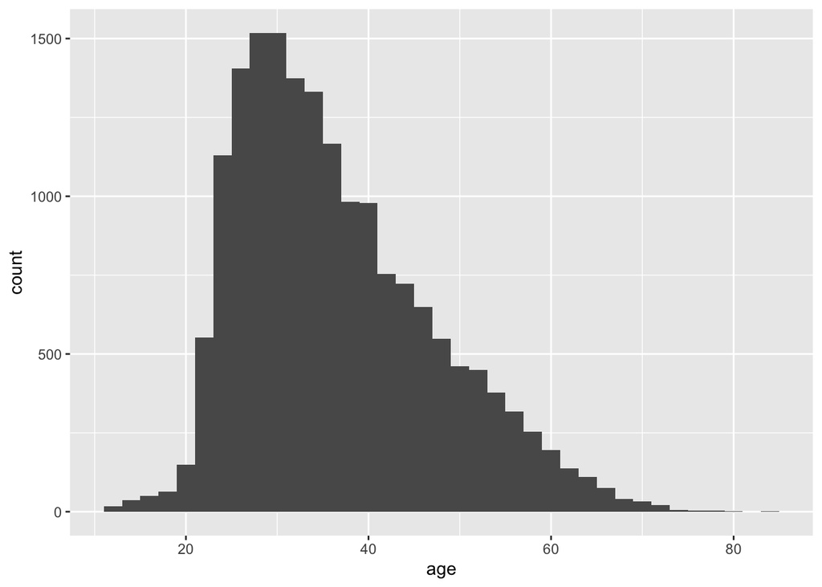

```r
run17 %>%
  filter(event == "10 Mile") %>%
  ggplot(mapping = aes(x = age)) +
    geom_histogram(binwidth = 2)
```

```r
# Calculate mean and median
run17 %>%
  filter(event == "10 Mile") %>%
  summarise(
    mean_age = mean(age, na.rm = TRUE),
    median_age = median(age, na.rm = TRUE),
  )
```

```
## # A tibble: 1 × 2
##   mean_age median_age
##      <dbl>      <dbl>
## 1     37.0         35
```

*(1)The histogram totally presents a right-skewed distribution, and there is a peak near 30 years old.(2)The distribution is not uniform but concentrated in specific age groups, more toward the younger people.(3)In the data presented in the table, the mean is about 37 years old, the median is 35 years old, and the mean is greater than the median to prove that the table is right skewed. According to the mean and median of the data, we can also find that this activity is more skewed towards young people, as the oldest age is 85 years old and the youngest age is 11 years old.*

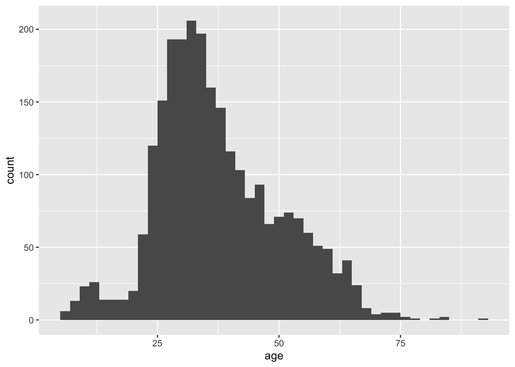

```r
# Write your code for Ex1b here
run17 %>%
  filter(event == "5K") %>%
  ggplot(mapping = aes(x = age)) +
    geom_histogram(binwidth = 2)
```

```r
# Calculate mean and median
run17 %>%
  filter(event == "5K") %>%
  summarise(
    mean_age = mean(age, na.rm = TRUE),
    median_age = median(age, na.rm = TRUE),
  )
```

```
## # A tibble: 1 × 2
##   mean_age median_age
##      <dbl>      <dbl>
## 1     38.0         36
```

*(1)The histogram totally presents a right-skewed distribution, and there is a peak near 32 years old.(2)Both the “5K” and “10 Mile” events represent a right-skewed distribution, and most runners are concentrated in one particular age group. However, both the median and the average are larger in the 5K than in the 10 Mile, indicating that the participants are relatively older.*

## Exercise 2

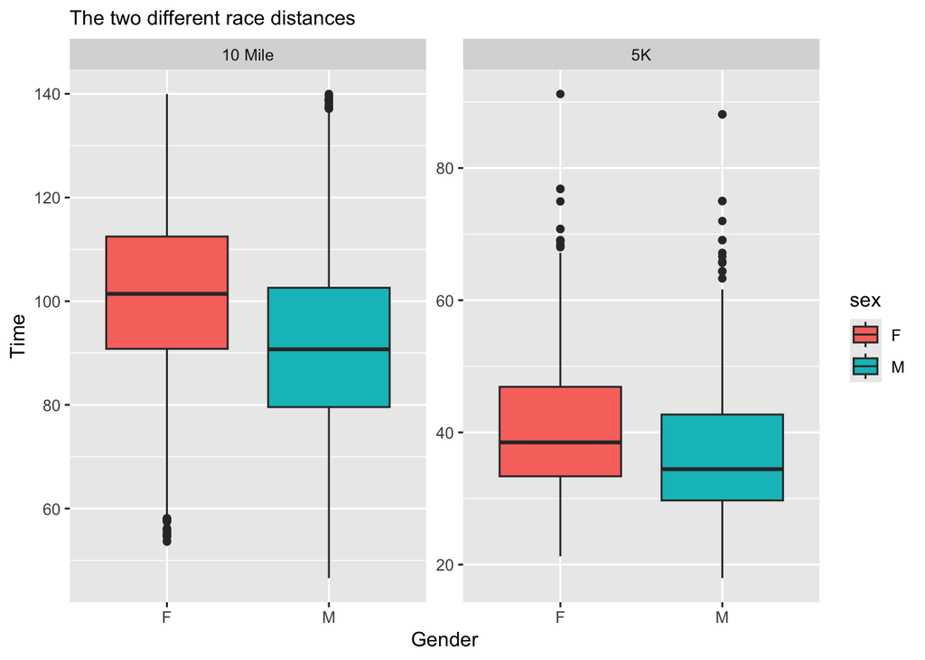

```r
# Write your code to answer exercise 2a here
# Data wrangling
run17_clean <- run17 %>%
  mutate(net_min = net_sec / 60) %>%
  select(net_min, sex, event) %>%
  drop_na()
# Data visualize
ggplot(run17_clean, aes(x = sex, y = net_min, fill = sex)) +
         geom_boxplot() +
         facet_wrap(~ event, scales = "free_y") +
         labs(tittle = "The time that it took the runners to complete the Cherryblossom race",
              x = "Gender",
              y = "Time",
              subtitle = "The two different race distances")
```

*In both events, male’s median is smaller than female’s, which means that male is faster than female overall.*

## Exercise 3

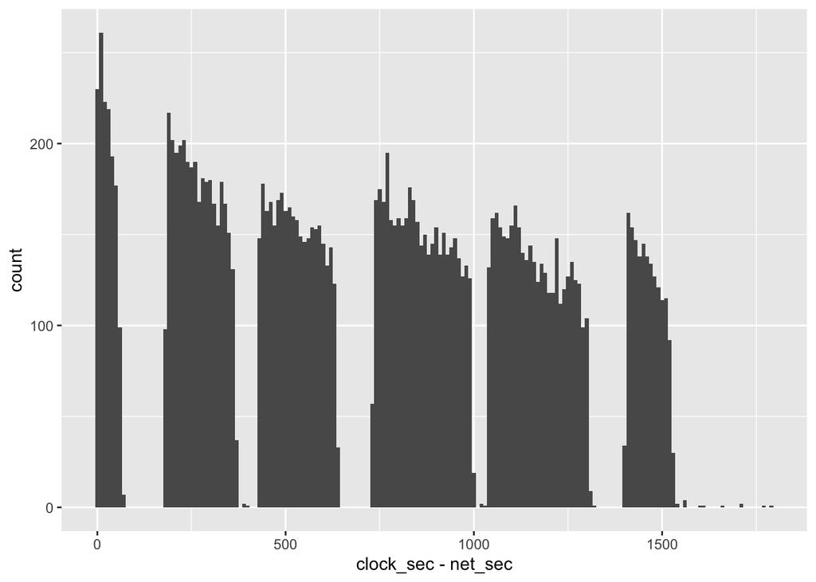

```r
# Write your code to answer exercise 3 here
ggplot(data = run17 %>% filter(event == "10 Mile"),
       mapping = aes(x = clock_sec - net_sec)) +
  geom_histogram(binwidth = 10)
```

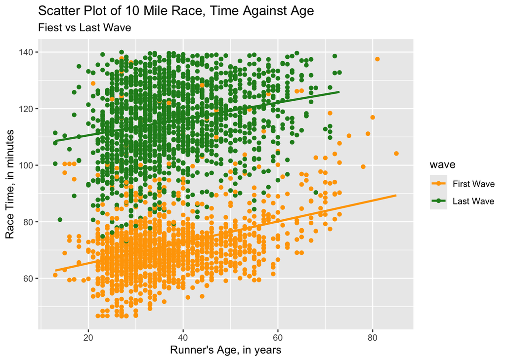

```r
# Data wrangling
run17_clean2 <- run17 %>%
  filter(event == "10 Mile") %>%
  mutate(begin_time = (clock_sec-net_sec)/60) %>%
  mutate(
    wave = case_when(
      begin_time <= 3 ~ "First Wave",
      begin_time >= 23 ~ "Last Wave"
    ),
    race_time = net_sec/60) %>%
  drop_na() %>%
  select(age, wave, race_time)
# Data visualize
ggplot(run17_clean2, aes(x = age, y = race_time, color = wave)) +
  geom_point() +
  geom_smooth(method = lm, se = FALSE) +
  labs(
    x = "Runner's Age, in years",
    y = "Race Time, in minutes",
    title = "Scatter Plot of 10 Mile Race, Time Against Age",
    subtitle = "Fiest vs Last Wave"
  ) +
  scale_color_manual(
    values = c("First Wave" = "orange", "Last Wave" = "forestgreen")
  )
```

## Exercise 4

#### Example of a good data visualisation

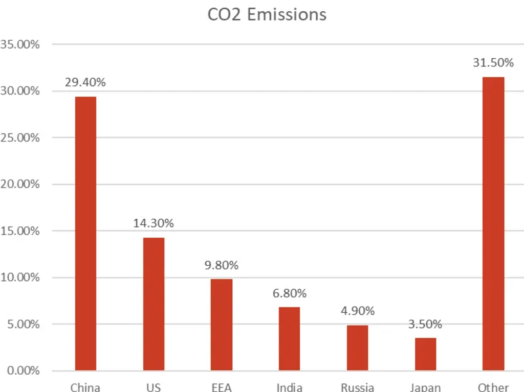

**Polymer**, “**10 Good and Bad Examples of Data Visualization in 2024**” [Online]. Available at: **https://www.polymersearch.com/blog/10-good-and-bad-examples-of-data-visualization** (Accessed: **01 November 2024**)

#### Example of a bad data visualisation

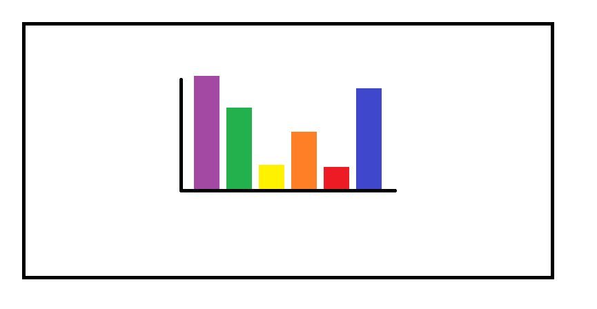

**Polymer**, “**10 Good and Bad Examples of Data Visualization in 2024**” [Online]. Available at: **https://www.polymersearch.com/blog/10-good-and-bad-examples-of-data-visualization** (Accessed: **01 November 2024**)